# Project1E

## Video 4: https://piazza.com/class/kxqetm8l564fv?cid=152

### What questions did you have?

```
A question that I have regarding the video is in relation to the student's limitations slide. The student brings up how there are limitation with de novo sequencing. I wonder if there is a better way to replicate this study with other methods and what those methods would be, if they exist.
```

### What did you like about the video?

```
One thing that I liked about the video is the appropriate key terms. Each of the terms were used readily in the rest of the presentation and thus were relevant in explaning each part of the presentation. Additionally, I like how he provided examples of each key term as they are new terms and may be difficult to understand.
```

### What was clear?

```
The take home findings were clear and directly answers the hypothesis and scientific question that the student presented at the beginning of the presentation. Each of the key findings were simple yet perfect in summarizing the authors findings.
```

### Was the figure that the author chose to review relevant?

```
The figure was relevant to the bioninformatics method. The student did a great job of explaning each part of the figure as shown in the text on the presentation and vocally explained. The student did a great job of explaining why the figure is important to the study and how it was obtained with the bioinformatics method.
```

### What was confusing?

```
It was hard to find something that was confusing about this video. However, if I had to choose something, it would be how the findings are applicable in future studies. The findings are interesting, but I'm confused how understanding electrical organs give a better understanding of organisms that branched off of these electrical organisms.
```

## Question from Video

### Because of the hierarchal clustering, we are able to see a phylogenetic tree to compare between species, but is hierarchal clustering the only method of doing species wide comparison to observe a specific trait?

There are not a lot of resources that point to another tool to address species wide comparisons. However, in lieu of finding such an article I found an article that compares hierarchal clustering with K means. K means is a method of cluster analysis that uses a pre-specified number of clusters and needs advance knowledge of K. This may be another was to analyze species wide comparisons given a specific trait. https://www.geeksforgeeks.org/difference-between-k-means-and-hierarchical-clustering/

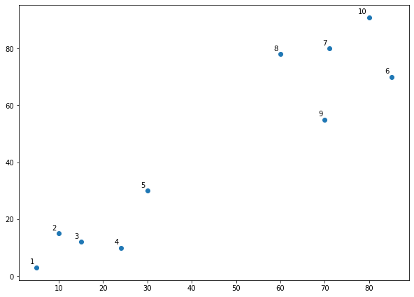

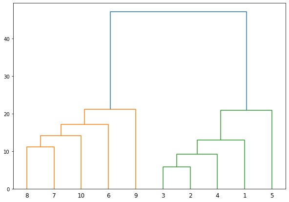

```python
#Genomic Basis for the Convergent Evolution of Electric Organs
#Hierarchal Clustering
import pandas as pd
import numpy as np
import matplotlib.pyplot as plt
%matplotlib inline

sample_data = np.array([[5,3],[10,15],[15,12],[24,10],[30,30],[85,70],[71,80],[60,78],[70,55],[80,91],])

labels = range (1,11)

plt.figure(figsize=(10,7))

plt.subplots_adjust(bottom=0.1)

plt.scatter(sample_data[:,0],
            sample_data[:,1],
            label='True Position')

for label, x, y in zip(labels,
                       sample_data[:,0],
                      sample_data[:,1]):
    plt.annotate(
            label,
            xy=(x,y), xytext=(-3,3),
            textcoords='offset points', ha='right',va = 'bottom')
plt.show()

from scipy.cluster.hierarchy import dendrogram, linkage

from matplotlib import pyplot as plt

linked=linkage(sample_data, 'single')

labelList=range(1,11)

plt.figure(figsize=(10,7))

dendrogram(linked,
              orientation='top',
              labels=labelList,
            distance_sort='descending',
            show_leaf_counts=True)
plt.show()


#There was nothing wrong with this code and is perfect :--)
```

## Video 5: https://piazza.com/class/kxqetm8l564fv?cid=131

### What questions did you have?

```
A question that I have in regards to this topic is regarding a limitation that the student discusses. I wonder if there will be different outcomes if the research cohort contained individuals of different socio-economic backgrounds where meditation is not readily achievable as there is not luxury of time.
```

### What did you like about the video?

```
I like how the key terms that are important in understanding the take home findings are explained in detail. It allows the audience to understand each part of the key findings as the new terms are well explained. I also liked how the student explained each part of their code. I think they did a great job in explaining each part of the code and present an outcome that shows a significant p-value.
```

### What was clear?

```
The take home findings were clear and directly answers the hypothesis and scientific question that the student presented at the beginning of the presentation. The findings are clear and easy to understand. The wording of the findings is simple that facilitates ease of understanding especially given the complex findings.
```

### Was the figure that the author chose to review relevant?

```
The figure was relevant to the bioninformatics method, and the student did a great job in explaning each part fo the figure in relation to their methods. I find that the text in the slide is perfect in summarizing the important parts of the figure and how they relate to the paper's findings.
```

### What was confusing?

```
One thing that I am confused about is how the authors were able to detect increase in cell telomerase activity in their study. I don't think that detail was mentioned in the presentation and thus confuses me on how the data was obtained.
```

## Question from Video

### How would these findings be used in the future for disease prevention and treatment?

There is a lot of clinical treatment applications of meditation in Alzheimer's Disease. From personal experience, I know that a lot of clinicians suggest their patients to do mindfulness activities and strongly suggest meditation. Evidence shows that meditation can improve some aspects of cognition but no evidence shows any means of prevention. In other words, it helps with overall wellbeing and is no direct treatment. https://www.alzdiscovery.org/cognitive-vitality/blog/meditation-its-effect-on-cognition-and-general-well-being#:~:text=Evidence%20suggests%20that%20meditation%20may,may%20improve%20general%20well%2Dbeing.

```python
#Meditation and Vacation Effects Have an Impact on Disease Associated Molecular Phenotypes
#P-values
import numpy as np
import pandas as pd
import scipy.stats as stats
import matplotlib.pyplot as plt
import math

np.random.seed(11)

before=stats.norm.rvs(scale=30,loc=250,size=100)

after=before+stats.norm.rvs(scale=5,loc=-1.25, size=100)

weight_df=pd.DataFrame({"weight_before":before,"weight_after":after,"weight_change":after-before})

weight_df.describe()

stats.ttest_rel (a=before, b=after)

#The code works :--)
```

```
Ttest_relResult(statistic=2.5720175998568284, pvalue=0.011596444318439857)
```

## Video 6: https://piazza.com/class/kxqetm8l564fv?cid=145

### What questions did you have?

```
A question that I have is how tranmission from species can be prevented given the findings from this paper. This may open avenues in preventing pandemics in the future.
```

### What did you like about the video?

```
I like how the student took a lot of time in explaining the key terms. It definitely allowed for the audience to get a better grasp of what exactly the study is testing and what their outcomes are. I also like how they included figures from the background paper from previous research.
```

### What was clear?

```
The take home findings in relation to the scientific question was very clear. The key finding shows exactly that the intermediate species was for the SARS-CoV-2. It was a little difficult to understand some portions of the hypothesis, but their take home findings slides made up for that confusions as it presents the findings in a simple yet easy to understand manner.
```

### Was the figure that the author chose to review relevant?

```
They did a great job explaining each figure. Each part of the figure was well explained but also they did a great job explaining the take home findings from each figure in relation to the scientific question.
```

### What was confusing?

```
I think the hypothesis of this video was hard to understand as there were too many parts to it. I would suggest that the hypothesis be condensed into a single sentence so that it doesn't raise the possibility in confusion.
```

## Question from Video

### Are there potentially other viruses that SARS-CoV-2 may resemble (excluding SARS-CoV-1)?

This article suggests that there are no other viruses that resemble SARS-CoV-2 other than its sister virus SARS-CoV-1.https://www.frontiersin.org/articles/10.3389/fmed.2020.594439/full However, I think that there should be more research done in identifying other viruses that can potentially induce another pandemic in the future due to its ease of transmission.

```python
#The Missing Link of COVID-19
#Relative Synomynous Codon Usage
import CAI
from CAI import RSCU

synseq = RSCU(["GAT","TTT"])
print(synseq)

synseq2 = RSCU(["AAA","TTA"])
print(synseq2)

synRSCU = {key: synseq[key] - synseq2.get(key,0) for key in synseq}
synRSCU = {key: synRSCU[key]**2 for key in synRSCU}
values = sum(synRSCU.values())

print(values)

#I was unable to import this package. But it seems like from the video they were successful
#in importing and obtaining the expected outcome.
```

[output not shown]